# Pristina TranscriptomicLandscape 01: DataLoad

Alberto Perez Posada @apposada

30/11/2022

## Loading Necessary Packages

```r
library(vroom)
library(reshape2)
library(ComplexHeatmap)
library(circlize)
library(viridis)
library(colorspace)
library(RColorBrewer)
library(dplyr)
library(stringr)
library(ggplot2)
library(gplots)
library(data.table)
library(DESeq2)
```

## Loading necessary code

```r
#courtesy from @Rich Scriven https://stackoverflow.com/questions/26045478/source-r-scripts-in-different-folders
sourceFolder <- function(folder, recursive = FALSE, ...)
{
    files <- list.files(folder, pattern = "[.][rR]$",
                        full.names = TRUE, recursive = recursive)
    if (!length(files))
        stop(simpleError(sprintf('No R files in folder "%s"', folder)))
    src <- invisible(lapply(files, source, ...))
    message(sprintf('%s files sourced from folder "%s"', length(src), folder))
}

sourceFolder(
  "/mnt/sda/alberto/projects/dev/comparABle/code/functions/", #change for definitive path once its final
  recursive = TRUE
  )
```

## Data Load

First we will load a table containing information of the different cell types to inform on cluster identity, annotate the plots with colors, etc.

```r
plei_ctypes <- read.delim2(
  "./data/01_celltypedata/plei_ctypes.tsv",
  header = T
)

plei_ctypes$leiden_sort <-
  factor(
    paste(
      formatC(plei_ctypes$Cluster, width = 2, format = "d", flag = "0"), #2-digit number of cluster
      plei_ctypes$Names_leiden_1.5, sep ="_" # name of the cluster
      ),
    levels = paste( # arrange cluster names by original ordering of the table (i.e. 'broad' cell type, hand-made order)
      formatC(plei_ctypes$Cluster, width = 2, format = "d", flag = "0"),
      plei_ctypes$Names_leiden_1.5, sep ="_"
    )
  )

plei_ctypes <- plei_ctypes[order(plei_ctypes$Cluster),] #sort by numeric order

#table cluster name - color, for annotating purposes
plei_ctypes_col <- data.frame(
  cluster = plei_ctypes$leiden_sort,
  col = plei_ctypes$Colours
)

plei_ctypes_col <- plei_ctypes_col[order(plei_ctypes_col$cluster),]
rownames(plei_ctypes_col) <-  NULL
plei_ctypes_col <- plei_ctypes_col[1:49,] # we discard unannotated clusters

head(plei_ctypes[,1:5])
```

```
##    Cluster   Names_leiden_1.5 Name_marker       Broad_Type Colours
## 5        0        epidermis_1                    epidermis #75CFEA
## 1        1   piwi_pos_cells_1               piwi_pos_cells #585858
## 2        2   piwi_pos_cells_2               piwi_pos_cells #9D9D9D
## 26       3          neurons_1                      neurons #FEC960
## 32       4 globin_pos_cells_1             globin_pos_cells #FD6B6B
## 21       5           muscle_1                       muscle #B22222
```

We begin our with a matrix of transcript counts summed at the pseudo-bulk level of narrow cell types.

```r
plei_counts_all <- vroom(
  "./data/02_geneexpression/Pristina_atlas_counts.tsv",
  col_names=T
)
```

```
## ──────────────────────────────────────────────────────── Delimiter: "\t" chr
## (1): ...1 dbl (60): 0, 1, 2, 3, 4, 5, 6, 7, 8, 9, 10, 11, 12, 13, 14, 15, 16,
## 17, 18, ...
```

```r
plei_counts_all[,2:61] <- plei_counts_all[,2:61] - 1 # remove one pseudocount added by Jordi

plei_counts <- as.data.frame(plei_counts_all)

rownames(plei_counts) <- plei_counts$...1
plei_counts$...1 <- NULL # remove gene names column

head(plei_counts[,1:5])
```

```
##                     0   1   2   3     4
## PrileiEVm000001t1  49  97  44  59    27
## PrileiEVm000002t1 212 181 169 183 26925
## PrileiEVm000003t1  39 175  59  20    30
## PrileiEVm000004t1 385   4  11  11    12
## PrileiEVm000005t1   9  58  36  11   283
## PrileiEVm000006t1  12  19  12  18    10
```

We set up the column names now. Because we arranged the table following cluster 0,1,… the naming order gets preserved. We also remove columns corresponding to un-annotated clusters (see Methods).

```r
colnames(plei_counts) <- plei_ctypes$leiden_sort #because we arranged the table following cluster 0,1,... the naming order gets preserved
plei_counts <- setcolorder(plei_counts, neworder = as.character(plei_ctypes_col$cluster)) # set column order by broadtype (see above)
plei_counts <- plei_counts[,1:49] #remove un-annotated clusters
```

We add a low, arbitrary threshold to remove the sparse genes that have less than 50 counts across all clusters.

```r
plei_counts <- plei_counts[rowSums(plei_counts) > 50,] # post-hoc estimated with the plot of hvg
head(plei_counts[,1:5])
```

```
##                   01_piwi_pos_cells_1 02_piwi_pos_cells_2 08_nidogen1_pos_cells
## PrileiEVm000001t1                  97                  44                    24
## PrileiEVm000002t1                 181                 169                   260
## PrileiEVm000003t1                 175                  59                    30
## PrileiEVm000004t1                   4                  11                    11
## PrileiEVm000005t1                  58                  36                    92
## PrileiEVm000006t1                  19                  12                     1
##                   18_epidermal_progenitors 00_epidermis_1
## PrileiEVm000001t1                        8             49
## PrileiEVm000002t1                       40            212
## PrileiEVm000003t1                       11             39
## PrileiEVm000004t1                       17            385
## PrileiEVm000005t1                        9              9
## PrileiEVm000006t1                        6             12
```

## Normalisation by library size

There are clusters with massively different sizes (i.e. clusters of thousands of cells vs clusters of hundreds).

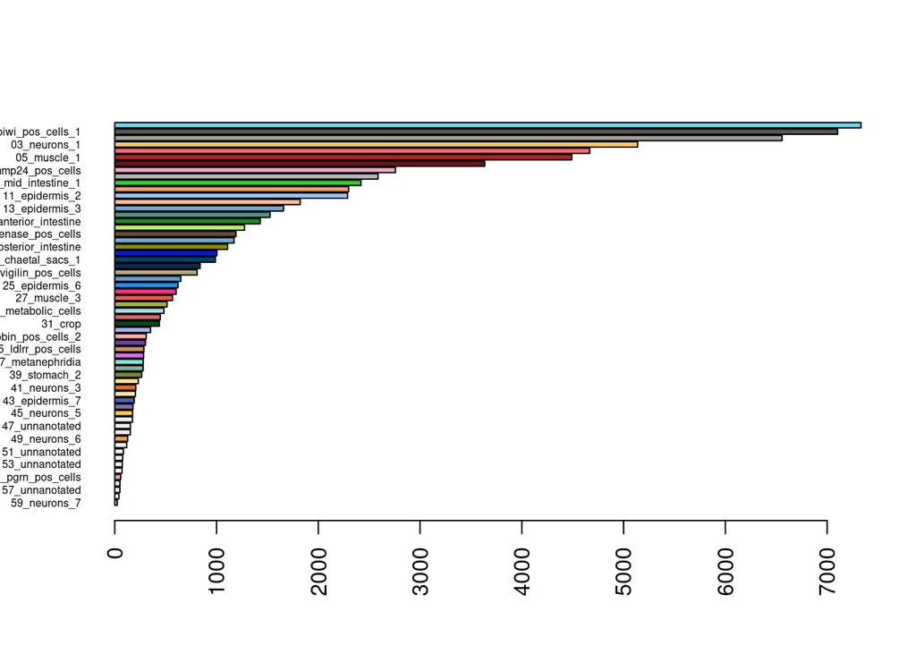

And if we check the distribution of counts per cluster:

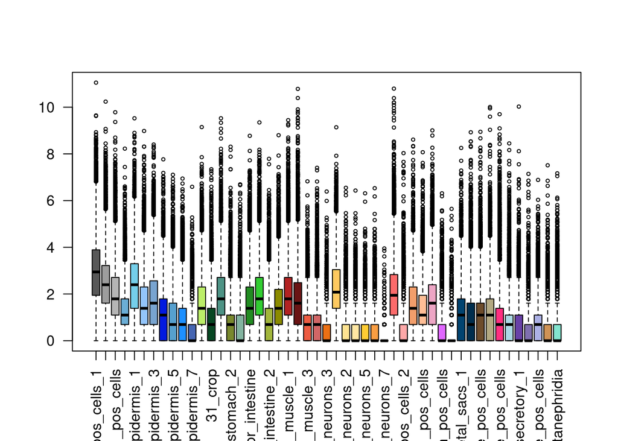

Since we are treating each cluster as a separate “condition”, one can expand this to consider them as separate RNA libraries. Thus we can apply normalisation methods by library composition such as DESeq2.

```r
plei_dds <- DESeqDataSetFromMatrix(countData = plei_counts,
                                   colData = data.frame(condition = colnames(plei_counts)),
                                   design = ~ condition)
plei_dds <- estimateSizeFactors(plei_dds)
plei_counts_norm <- counts(plei_dds, normalized=TRUE)

head(plei_counts_norm[,1:5])
```

```
##                   01_piwi_pos_cells_1 02_piwi_pos_cells_2 08_nidogen1_pos_cells
## PrileiEVm000001t1           4.3680279           3.9001595             3.8559089
## PrileiEVm000002t1           8.1506501          14.9801581            41.7723468
## PrileiEVm000003t1           7.8804628           5.2297593             4.8198862
## PrileiEVm000004t1           0.1801249           0.9750399             1.7672916
## PrileiEVm000005t1           2.6118105           3.1910396            14.7809842
## PrileiEVm000006t1           0.8555931           1.0636799             0.1606629
##                   18_epidermal_progenitors 00_epidermis_1
## PrileiEVm000001t1                 4.672612       6.679450
## PrileiEVm000002t1                23.363062      28.898843
## PrileiEVm000003t1                 6.424842       5.316297
## PrileiEVm000004t1                 9.929302      52.481390
## PrileiEVm000005t1                 5.256689       1.226838
## PrileiEVm000006t1                 3.504459       1.635784
```

Here below are plots of the expression of the first 200 genes in two different clusters, before and after normalisation. We can observe how these genes “behave” similarly before and after normalisation, but the range of variation is much more similar between clusters regardless of their size in cells.

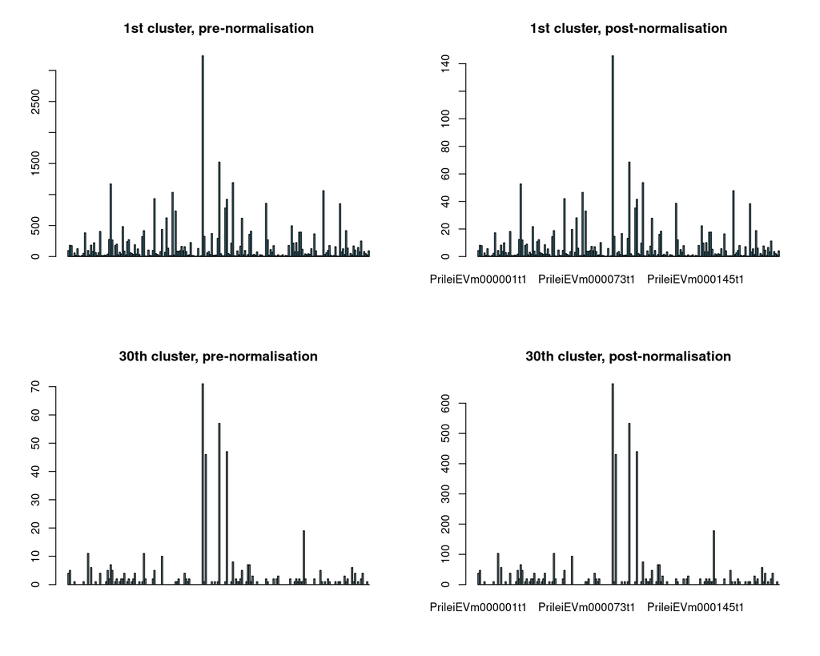

A birds-eye view of this across all clusters:

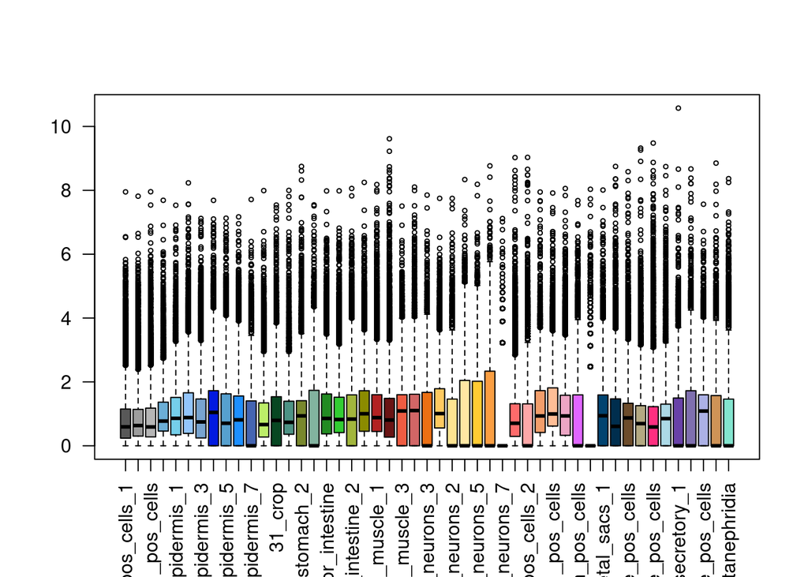

This method is not perfect but it is accurate enough for our purpose.

## Counts-per-million normalisation

We normalise the DESeq2-normalised (pseudo)counts as counts-per-million (CPM)

```r
plei_cpm <- apply(
  plei_counts_norm,
  2,
  function(x) {x * 1e6 / sum (x)}
)
rownames(plei_cpm) <- rownames(plei_counts)
plei_cpm <- as.data.frame(plei_cpm)
```

Visual comprobation:

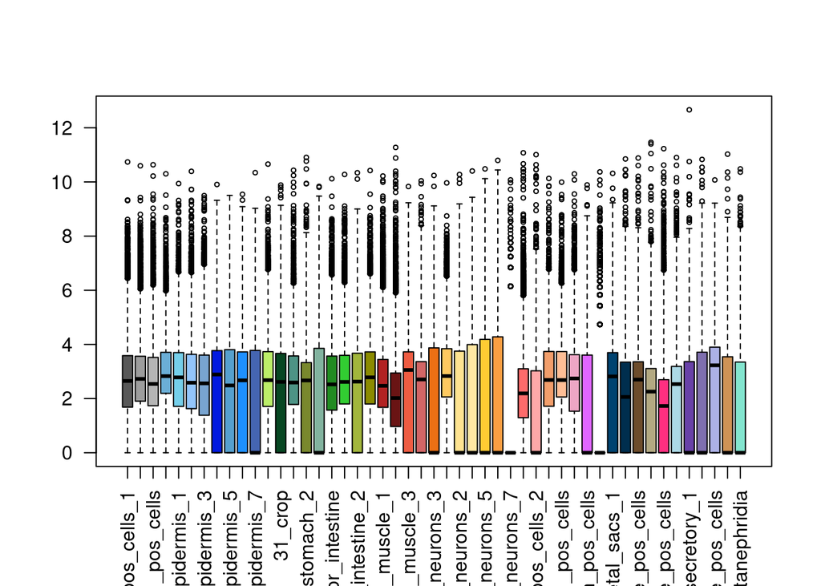

Is there any column that was not normalised to CPM?

```r
colSums(plei_cpm)
```

```
##             01_piwi_pos_cells_1             02_piwi_pos_cells_2
##                         1000000                         1000000
##           08_nidogen1_pos_cells        18_epidermal_progenitors
##                         1000000                         1000000
##                  00_epidermis_1                  11_epidermis_2
##                         1000000                         1000000
##                  13_epidermis_3                  20_epidermis_4
##                         1000000                         1000000
##                  24_epidermis_5                  25_epidermis_6
##                         1000000                         1000000
##                  43_epidermis_7              16_gut_progenitors
##                         1000000                         1000000
##                         31_crop                    14_stomach_1
##                         1000000                         1000000
##                    39_stomach_2           38_caveolin_pos_cells
##                         1000000                         1000000
##           15_anterior_intestine     09_anterior_mid_intestine_1
##                         1000000                         1000000
##     28_anterior_mid_intestine_2          19_posterior_intestine
##                         1000000                         1000000
##                     05_muscle_1                     06_muscle_2
##                         1000000                         1000000
##                     27_muscle_3                     30_muscle_4
##                         1000000                         1000000
##                    41_neurons_3                    03_neurons_1
##                         1000000                         1000000
##                    40_neurons_2                    42_neurons_4
##                         1000000                         1000000
##                    45_neurons_5                    49_neurons_6
##                         1000000                         1000000
##                    59_neurons_7           04_globin_pos_cells_1
##                         1000000                         1000000
##           33_globin_pos_cells_2       10_polycystin_2_pos_cells
##                         1000000                         1000000
##       12_polycystin_1_pos_cells              07_mmp24_pos_cells
##                         1000000                         1000000
##         36_fucolectin_pos_cells               55_pgrn_pos_cells
##                         1000000                         1000000
##               21_chaetal_sacs_1               22_chaetal_sacs_2
##                         1000000                         1000000
##       17_lipoxygenase_pos_cells            23_vigilin_pos_cells
##                         1000000                         1000000
##       26_lumbrokinase_pos_cells 29_carbohydrate_metabolic_cells
##                         1000000                         1000000
##                  34_secretory_1                  44_secretory_2
##                         1000000                         1000000
##           32_arginase_pos_cells              35_ldlrr_pos_cells
##                         1000000                         1000000
##                37_metanephridia
##                         1000000
```

## Detecting highly variable genes

With normalised data, we can explore the expression variability of genes across clusters of cells. For this, we will extract the coefficient of variation (sd/mean) of every gene and the sum of counts of every gene across cell clusters.

```r
plei_counts_cv <- merge(
  data.frame(
    id = rownames(plei_counts),
    counts = as.numeric(rowSums(plei_counts))
  ),
  data.frame(
    id = rownames(plei_cpm),
  cv = apply(
    plei_cpm[,1:49],
    1,
    function(x){
      sd(x)/mean(x)
    }
  )
  ),
  by.x = 1,
  by.y = 1
)
head(plei_counts_cv)
```

```
##                  id counts        cv
## 1 PrileiEVm000001t1    627 0.7936985
## 2 PrileiEVm000002t1  35123 2.9897811
## 3 PrileiEVm000003t1    625 1.9848184
## 4 PrileiEVm000004t1   1150 2.0009814
## 5 PrileiEVm000005t1   1907 2.2462040
## 6 PrileiEVm000006t1   1174 5.6112954
```

We can visualise how the coefficient of variation of a given gene behaves depending on the abundance of the gene across cell clusters.

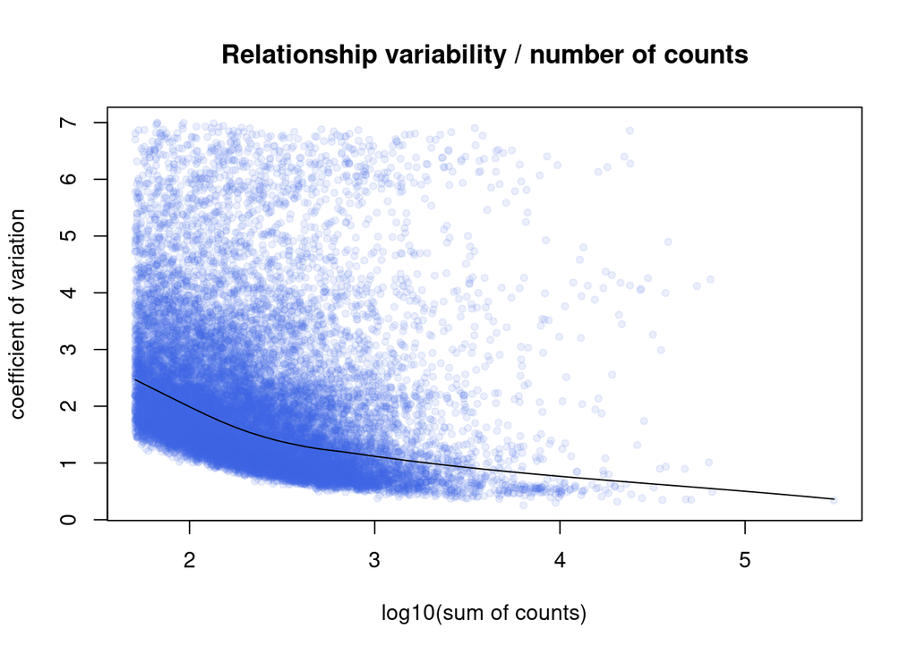

A loess fitting of the data allows for the detection of genes with high coefficient of variation as function of their expression level

```r
#' Loess fitting to generate the highly variable gene set
plei_loess <- loess(
  plei_counts_cv$cv ~ log(plei_counts_cv$counts),
  span= 1,
  family = "symmetric"
)

filt <- which(plei_loess$residuals > 0) #firs iteration this was 1
plei_hvg <- data.frame(id = rownames(plei_counts_cv$cv[filt]))
```

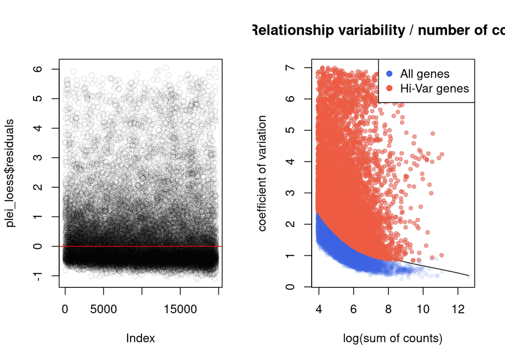

These so-called highly variable genes (HVG) comprise nearly fifty percent of the total genes used in the downstream analysis.

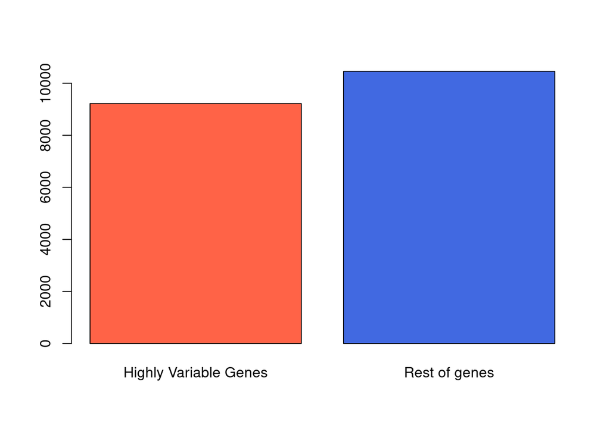

## Defining broad cell types: co-occurrence of cell cluster similarity

We can use a survival clustering approach (Levy et al., 2021) to infer what are the most similar cell type clusters. We will apply a soft threshold for genes with CV higher than 0.25.

```r
# comparABle function 'tidyup' from source
plei_cpm_cooc = tidyup(plei_cpm, highlyvariable = T)

# set fixed seed
set.seed(4343)
h <- c(0.75,0.95)
clustering_algorithm <- "hclust"
clustering_method <- "average"
cor_method <- "pearson"
p <- 0.1
vargenes = rownames(plei_cpm_cooc)

# Levy et al 2021 'treeFromEnsembleClustering' from source
cooc <- treeFromEnsembleClustering(
  x=plei_cpm_cooc, p=0.1, h=h,  n = 1000, vargenes = vargenes, bootstrap=FALSE,
  clustering_algorithm=clustering_algorithm, clustering_method=clustering_method,
  cor_method=cor_method
)
```

The resulting heatmap of similarity:

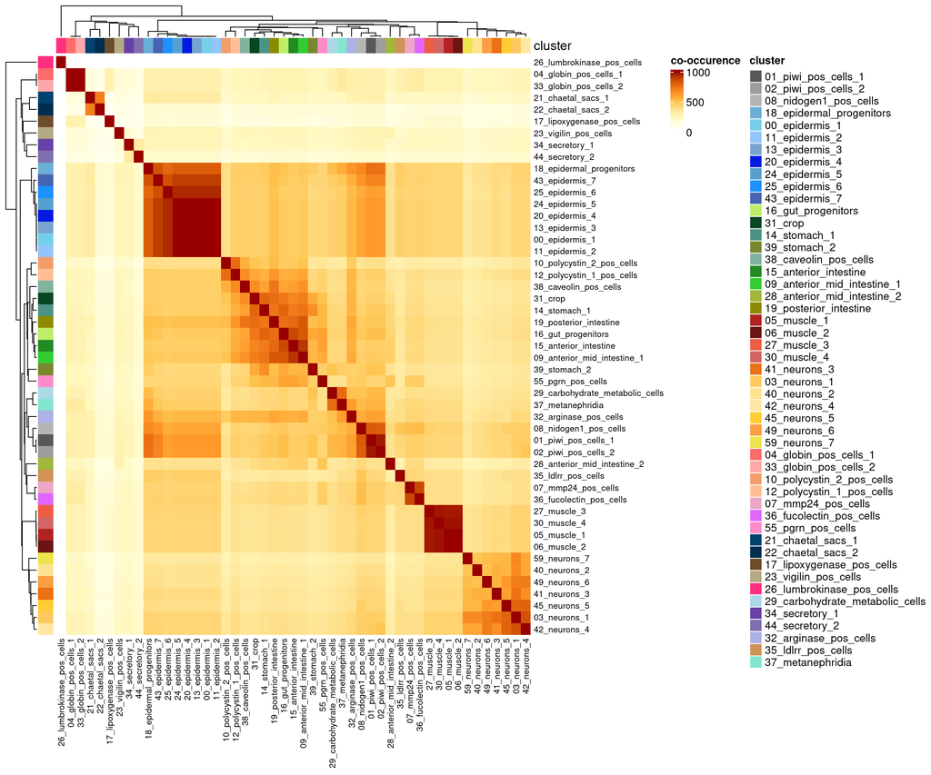

## One last bit

One last bit: a binning system for every gene to have an approximation of their peak of gene expression. We will go through this more thoroughly when doing the WGCNA analysis, but this can also be of good use.

```r
plei_genecolor <- data.frame(
  id = rownames(plei_cpm),
  genecolor = sapply(
    rownames(plei_cpm),
    function(x) {
      a <- which( rownames(plei_cpm) == x )
      b <- which( plei_cpm[a,] == max(plei_cpm[a,]) ) # which is the highest value of gene i, ie in which ctype is highest
      c <- colnames(
        plei_cpm[a,][b] # grab the name of the cell type where eigengene i is highest
      )
      d <- plei_ctypes_col$col[plei_ctypes_col$cluster == c] #sub("X","",c) # replace some characters
      return(d) # assign in the table
    }
  )
)

head(plei_genecolor)
```

```
##                                  id genecolor
## PrileiEVm000001t1 PrileiEVm000001t1   #FA9E42
## PrileiEVm000002t1 PrileiEVm000002t1   #FD6B6B
## PrileiEVm000003t1 PrileiEVm000003t1   #ECE44C
## PrileiEVm000004t1 PrileiEVm000004t1   #78A4D0
## PrileiEVm000005t1 PrileiEVm000005t1   #D26666
## PrileiEVm000006t1 PrileiEVm000006t1   #FFBE96
```

## Saving the data

We will save the important bits for further analysis in the rest of markdowns. (Note: this and “plei_modules_graph_annotation” object from Markdown #05 are the same.)

```r
save(
  # cell type table(s)
  plei_ctypes,
  plei_ctypes_col,
  # gene expression data
  plei_counts,
  plei_counts_norm,
  plei_cpm,
  # highly-variable genes
  plei_hvg,
  # visual annotations
  ctypes_rowAnno,
  clu_ha,
  plei_genecolor,
  # destination
  file = paste0(
    "./outputs/rda/",
    "01_plei_dataload.rda"
  )
)
```